# R Homework

*6. Comparation between hindfoot length under each plot type*

Plot 7 is supposed to compare among datasets. It is continuation from plot 6. After knowing the correlation, variance, and evidence levels, we want to compare 5 plot types to determine the best fit model.

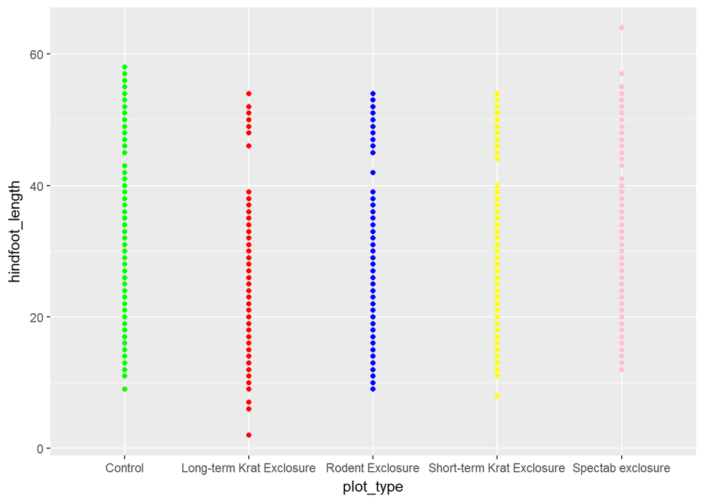

```r
#Check the relationship and dispersal each plot
        length_control <- surveys_combined_clear%>%
          select(hindfoot_length, plot_type , genus) %>%
          filter(plot_type == "Control")

        length_Longterm <- surveys_combined_clear %>%
          select(hindfoot_length, plot_type , genus) %>%
          filter(plot_type == "Long-term Krat Exclosure")

        length_rodent <- surveys_combined_clear %>%
          select(hindfoot_length, plot_type , genus) %>%
          filter(plot_type == "Rodent Exclosure")

        length_shortterm <- surveys_combined_clear %>%
          select(hindfoot_length, plot_type , genus) %>%
          filter(plot_type == "Short-term Krat Exclosure")

        length_spectab <- surveys_combined_clear %>%
          select(hindfoot_length, plot_type , genus) %>%
          filter(plot_type == "Spectab exclosure")

        #Ggplot hindfoot_length and plot_type
          ggplot() +
          geom_point(data = length_control, aes(x=plot_type, y=hindfoot_length),
                     color = 'green') +
          geom_point(data = length_Longterm, aes(x=plot_type, y=hindfoot_length),
                     color = 'red') +
          geom_point(data = length_rodent, aes(x=plot_type, y=hindfoot_length),
                     color = 'blue') +
          geom_point(data = length_shortterm, aes(x=plot_type, y=hindfoot_length),
                     color = 'yellow') +
          geom_point(data = length_spectab, aes(x=plot_type, y=hindfoot_length),
                     color = 'pink')
```

To compare 5 variables should be done with Anova. However, it is challenging to combine 5 datasets and arrange them in associated columns. Nonetheless, from given graph, it looks like control and spectab resulting higher hindfoot_length and the resf of them; Long-term, short-term and rodent exclosure are relatively same. Hence, depending on purpose, we could select which methods we would use.